# Crash course - Decoding Road accidents in the USA

## Artificial Neural Network

#### Vitalia Vedenikova and Perez Olusese worked on this model

Another method well adapted in theory to the prediction or classification of severity of accidents are Neural Networks. This method does however involve significantly more computing power than a Support Vector Machine model, which means that its application is more time consuming and prone to errors. Because of this, we had to remove cities populations from our predictors. Same as for the SVM, we used a balanced data set where the count of major and minor accidents is equal.

As further steps, we encoded dummy variables, normalized the numerical variables and lastly partitioned our data for training. We also made sure that the formula for our model was correctly defined in order to avoid using wrong predictors.

Then, we look at the different models:

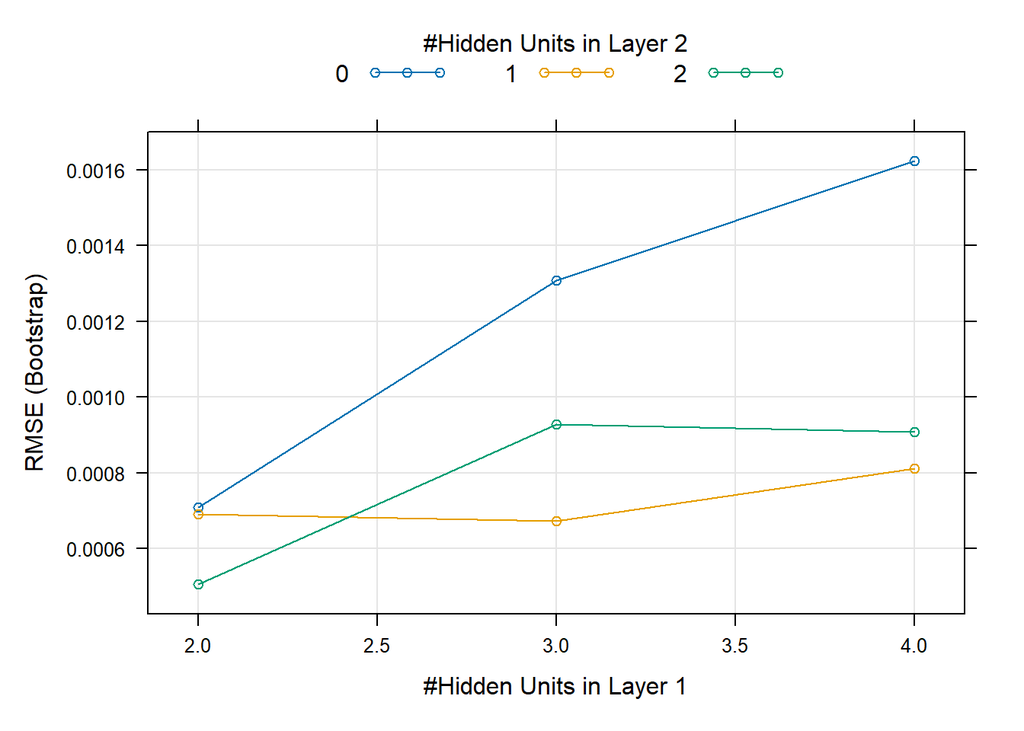

```r
#We will implement parallel processing to make the process more efficient:
library(doParallel)
cl <- makePSOCKcluster(detectCores() - 1)
registerDoParallel(cl)

#Then we optimize the network structure
set.seed(142)

models <- train(formula, train_mod,
               method="neuralnet",
               tuneGrid = expand.grid(.layer1=c(2:4), .layer2=c(0:2), .layer3=c(0)),
               learningrate = 0.001,
               threshold = 0.05,
               stepmax = 70000
)

#stop the cluster
stopCluster(cl)
registerDoSEQ()

plot(models)
```

```r
#We will implement parallel processing to make the process more efficient:
cl <- makePSOCKcluster(detectCores() - 1)
registerDoParallel(cl)

#We implement the best model:
set.seed(42)
best_model <- neuralnet(
    formula,
    train,
    hidden = c(2),
    learningrate = 0.001,
    threshold = 0.05,
    stepmax = 100000
  )

#stop the cluster
stopCluster(cl)
registerDoSEQ()

#We look at the confusion matrix and evaluate our model:
test_results <- neuralnet::compute(best_model, test_in)
test_pred <- apply(test_results$net.result, 1, which.max)
test_pred <- factor(levels(test_truth)[test_pred], levels = levels(test_truth))
confusionMatrix(test_truth, test_pred)
```

```
## Confusion Matrix and Statistics
##
##           Reference
## Prediction   0   1
##          0 589 412
##          1 295 706
##
##                Accuracy : 0.6469
##                  95% CI : (0.6255, 0.6678)
##     No Information Rate : 0.5584
##     P-Value [Acc > NIR] : 5.245e-16
##
##                   Kappa : 0.2937
##
##  Mcnemar's Test P-Value : 1.285e-05
##
##             Sensitivity : 0.6663
##             Specificity : 0.6315
##          Pos Pred Value : 0.5884
##          Neg Pred Value : 0.7053
##              Prevalence : 0.4416
##          Detection Rate : 0.2942
##    Detection Prevalence : 0.5000
##       Balanced Accuracy : 0.6489
##
##        'Positive' Class : 0
##
```

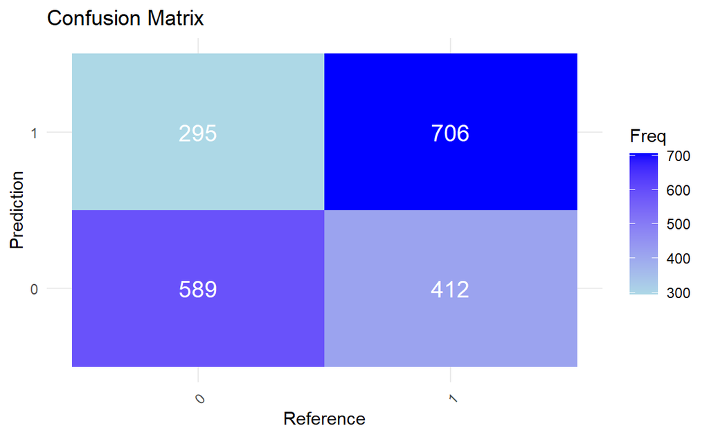

Note that while this is not shown here, we did run tests with many different settings for hidden layers, the learning rate and the stepmax. We are only showing the optimal model in terms of accuracy and other metrics.

The accuracy of our Neural Network Model is of 65%, which is slighlty lower than that of the Support Vector Machine. Its specificity, which refers to the true negative rate, is much lower at 63%. Furthermore, its precision is much lower at 59%, so it does not identify positive cases very well. It does however identify negative cases better with a rate of 71% compared to the rate of 67% from the SVM. It is also more dispersed, since its confidence interval is larger than that of the SVM model. Surprisingly, it seems to be much worse than the SVM at predicting serious accidents, since a lot of them were misclassified as low severity. This is concerning and would lead us to prefer the SVM model, which does misclassify minor accidents as serious more often, but would prove less risky to use as a prediction model in a real life scenario. Indeed, it would be better to identify accidents as serious than minor in most cases.

## Conclusion

After investigating our three main topics of the duration, amount and severity of car accidents in the USA, we draw the following overall conclusions:

We found that US States, months and the interaction term between severity and street type all had a strong association with the duration of an accident. Our GAM model also revealed a possible influence from temperature levels and cities’ populations. In particular, a sharp increase in duration coincided with higher severity levels, suggesting a positive correlation. Interestingly, the weather conditions did not appear to have much importance, since it took less time to deal with accidents in January than in warmer months. Perhaps emergency services’ response times are already optimized for all weather conditions. Nevertheless, Los Angeles stood out in how long its durations are, so a separate, in-depth study of this State’s road infrastructure is advised.

From our models we also found that weather conditions show evidence that they do affect accident occurrence. This is evidenced by the fact that the number of accidents per state are affected by certain weather conditions.

When it comes to measuring severity, it is evident from our models that junctions increase the chances of severe road accidents, perhaps because bad drivers might not slow down at those places. Perhaps accident-prone junctions need to be identified and replaced with roundabouts.

Ultimately, the predictors we identified allowed us to fit Support Vector Machine and Neural Network prediction models that were capable of predicting severity of accidents up to a 68% level of accuracy. To increase their prediction power, more highly correlated variables could be identified and previous years considered in our data set.

## Use of Generative AI

We utilized ChatGPT-3.5 to enhance the structure and grammar of our report, ensuring clarity and professionalism. It assisted us in understanding and resolving errors encountered during the coding process. Additionally, ChatGPT-3.5 provided valuable guidance and structure when certain aspects were unclear, helping us to articulate our ideas more effectively and maintain a cohesive flow throughout the report. Since we did not have much experience with functions in R, we also used it to help us define certain variables in the data preparation process and to experiment with sampling methods for the four levels of severity in the context of the SVM and ANN models.

## Reflection

This project presented a steep learning curve for us as a team of two people, but it offered invaluable insights into the real-world tasks and responsibilities of data scientists. During the process, we encountered numerous challenges that tested our problem-solving skills and deepened our statistical knowledge. We gained hands-on experience with data collection, cleaning, and preprocessing, which made us realize the importance of data preparation. Analyzing complex datasets and applying advanced statistical methods allowed us to see the practical applications of theoretical concepts we learned. Moreover, we realized how difficult it could be to build machine learning models and draw meaningful conclusions from our findings. Overall, this project truly enhanced our technical skills and adaptability as data scientists.